# STAT 331 Portfolio

## Program Efficiency

**PE-1: I can write concise code which does not repeat itself.**

- using a single function call Lab 5 q 4

```r
grouped_data <- surveys %>%
  group_by(year, genus) %>%
  summarize(mean_weight = mean(weight), .groups = "drop")

grouped_data$genus <- fct_reorder(grouped_data$genus, grouped_data$mean_weight)

p <- ggplot(data = grouped_data, mapping = aes(x = year, y = mean_weight, color = genus)) +
  geom_line() +
  scale_x_continuous(limits = range(grouped_data$year), expand = c(0, 0)) +
  scale_y_continuous(limits = range(grouped_data$mean_weight), expand = c(0, 0)) +
  labs(x = "Year", y = "Mean Weight") +
  ggtitle("Mean Weight Over Time")
  theme_classic() +
  theme(legend.position = "bottom")
```

We have not gotten to this point yet in class

**PE-2: I can write functions to reduce repetition in my code.**

**PE-3:I can use iteration to reduce repetition in my code.**

**PE-4: I can use modern tools when carrying out my analysis.**

## Data Simulation & Modeling

**DSM-1: I can simulate data from a *variety* of probability models.**

**DSM-2: I can fit a linear regression and extract necessary summary measures.**

## Revising My Thinking

In general, when learning a new programming language like R, the process of revision is a critical aspect of the learning experience. As i have progressed through the intro to R programming course, i found my understanding of the language developing and I began to approach coding problems differently. For example, I started to appreciate the importance of clear and concise coding practices, and using functions and packages in more advanced ways. Additionally, i found my overall understanding of the language to increase and i feel that this is apparent in my portfolio. One thing that really allowed me to learn this quarter was the amount of feedback i was receiving for my work. In a lot of my past classes my grading feedback often came down to an auto grader that would tell me what cases id fail and that was it. this class has really allowed me to understand the problems i was making from a coding stand point as well as a conceptual standpoint.

## Peer Support & Collaboration

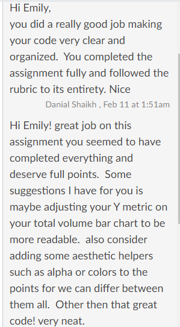

I think this is a great example of good feedback from me to my peers because in most cases my classmates are doing a very good job with their code but they still have smaller aesthetic mishaps that they could fix in the future. I try to do my best helping my classmates outside of class when it comes to discord and within our practice activities I have always did my best to contribute to the group.